# Lab 9 Homework

Ibrahim Rizk

2021-03-01

## Instructions

Answer the following questions and complete the exercises in RMarkdown. Please embed all of your code and push your final work to your repository. Your final lab report should be organized, clean, and run free from errors. Remember, you must remove the `#` for the included code chunks to run. Be sure to add your name to the author header above.

Make sure to use the formatting conventions of RMarkdown to make your report neat and clean!

## Load the libraries

```r
library(tidyverse)
library(janitor)
library(here)
library(naniar)
```

For this homework, we will take a departure from biological data and use data about California colleges. These data are a subset of the national college scorecard (https://collegescorecard.ed.gov/data/). Load the `ca_college_data.csv` as a new object called `colleges`.

```r
colleges <- read_csv('data/ca_college_data.csv')
colleges
```

```
## # A tibble: 341 x 10
##    INSTNM     CITY   STABBR ZIP   ADM_RATE SAT_AVG PCIP26 COSTT4_A C150_4_POOLED
##    <chr>      <chr>  <chr>  <chr>    <dbl>   <dbl>  <dbl>    <dbl>         <dbl>
##  1 Grossmont~ El Ca~ CA     9202~       NA      NA 0.0016     7956        NA
##  2 College o~ Visal~ CA     9327~       NA      NA 0.0066     8109        NA
##  3 College o~ San M~ CA     9440~       NA      NA 0.0038     8278        NA
##  4 Ventura C~ Ventu~ CA     9300~       NA      NA 0.0035     8407        NA
##  5 Oxnard Co~ Oxnard CA     9303~       NA      NA 0.0085     8516        NA
##  6 Moorpark ~ Moorp~ CA     9302~       NA      NA 0.0151     8577        NA
##  7 Skyline C~ San B~ CA     9406~       NA      NA 0          8580         0.233
##  8 Glendale ~ Glend~ CA     9120~       NA      NA 0.002      9181        NA
##  9 Citrus Co~ Glend~ CA     9174~       NA      NA 0.0021     9281        NA
## 10 Fresno Ci~ Fresno CA     93741       NA      NA 0.0324     9370        NA
## # ... with 331 more rows, and 1 more variable: PFTFTUG1_EF <dbl>
```

The variables are a bit hard to decipher, here is a key:

INSTNM: Institution name  
CITY: California city  
STABBR: Location state  
ZIP: Zip code  
ADM_RATE: Admission rate  
SAT_AVG: SAT average score  
PCIP26: Percentage of degrees awarded in Biological And Biomedical Sciences  
COSTT4_A: Annual cost of attendance  
C150_4_POOLED: 4-year completion rate  
PFTFTUG1_EF: Percentage of undergraduate students who are first-time, full-time degree/certificate-seeking undergraduate students

1. Use your preferred function(s) to have a look at the data and get an idea of its structure. Make sure you summarize NA’s and determine whether or not the data are tidy. You may also consider dealing with any naming issues.

```r
naniar::miss_var_summary(colleges)
```

```
## # A tibble: 10 x 3
##    variable      n_miss pct_miss
##    <chr>          <int>    <dbl>
##  1 SAT_AVG          276     80.9
##  2 ADM_RATE         240     70.4
##  3 C150_4_POOLED    221     64.8
##  4 COSTT4_A         124     36.4
##  5 PFTFTUG1_EF       53     15.5
##  6 PCIP26            35     10.3
##  7 INSTNM             0      0
##  8 CITY               0      0
##  9 STABBR             0      0
## 10 ZIP                0      0
```

```r
skimr::skim(colleges)
```

Data summary

| Name | colleges |
| --- | --- |
| Number of rows | 341 |
| Number of columns | 10 |
| _______________________ |  |
| Column type frequency: |  |
| character | 4 |
| numeric | 6 |
| ________________________ |  |
| Group variables | None |

**Variable type: character**

| skim_variable | n_missing | complete_rate | min | max | empty | n_unique | whitespace |
| --- | --- | --- | --- | --- | --- | --- | --- |
| INSTNM | 0 | 1 | 10 | 63 | 0 | 341 | 0 |
| CITY | 0 | 1 | 4 | 19 | 0 | 161 | 0 |
| STABBR | 0 | 1 | 2 | 2 | 0 | 3 | 0 |
| ZIP | 0 | 1 | 5 | 10 | 0 | 324 | 0 |

**Variable type: numeric**

| skim_variable | n_missing | complete_rate | mean | sd | p0 | p25 | p50 | p75 | p100 | hist |
| --- | --- | --- | --- | --- | --- | --- | --- | --- | --- | --- |
| ADM_RATE | 240 | 0.30 | 0.59 | 0.23 | 0.08 | 0.46 | 0.64 | 0.75 | 1.00 | ▂▃▆▇▃ |
| SAT_AVG | 276 | 0.19 | 1112.31 | 170.80 | 870.00 | 985.00 | 1078.00 | 1237.00 | 1555.00 | ▇▇▅▂▂ |
| PCIP26 | 35 | 0.90 | 0.02 | 0.04 | 0.00 | 0.00 | 0.00 | 0.02 | 0.22 | ▇▁▁▁▁ |
| COSTT4_A | 124 | 0.64 | 26685.17 | 18122.70 | 7956.00 | 12578.00 | 16591.00 | 39289.00 | 69355.00 | ▇▂▂▁▂ |
| C150_4_POOLED | 221 | 0.35 | 0.57 | 0.21 | 0.06 | 0.43 | 0.58 | 0.72 | 0.96 | ▂▃▇▇▅ |
| PFTFTUG1_EF | 53 | 0.84 | 0.56 | 0.29 | 0.01 | 0.32 | 0.50 | 0.81 | 1.00 | ▃▇▆▅▇ |

```r
colleges %>%
  summarize_all(~(sum(is.na(.))))
```

```
## # A tibble: 1 x 10
##   INSTNM  CITY STABBR   ZIP ADM_RATE SAT_AVG PCIP26 COSTT4_A C150_4_POOLED
##    <int> <int>  <int> <int>    <int>   <int>  <int>    <int>         <int>
## 1      0     0      0     0      240     276     35      124           221
## # ... with 1 more variable: PFTFTUG1_EF <int>
```

```r
colleges <- clean_names(colleges)
```

2. Which cities in California have the highest number of colleges?

```r
colleges %>%
  count(stabbr, city, sort = T )
```

```
## # A tibble: 161 x 3
##    stabbr city              n
##    <chr>  <chr>         <int>
##  1 CA     Los Angeles      24
##  2 CA     San Diego        18
##  3 CA     San Francisco    15
##  4 CA     Sacramento       10
##  5 CA     Berkeley          9
##  6 CA     Oakland           9
##  7 CA     Claremont         7
##  8 CA     Pasadena          6
##  9 CA     Fresno            5
## 10 CA     Irvine            5
## # ... with 151 more rows
```

```r
#Los Angeles, San Diego, and San Francisco have the highest number of colleges
```

3. Based on your answer to #2, make a plot that shows the number of colleges in the top 10 cities.

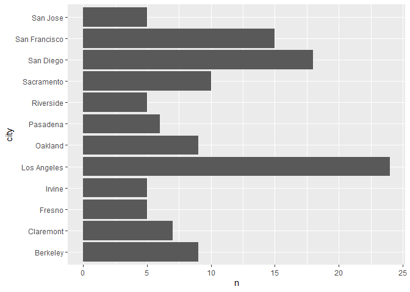

```r
colleges %>%
  count(city) %>%
  top_n(10, n) %>%
  ggplot(aes(x = city, y = n)) + geom_col() + coord_flip()
```

4. The column `COSTT4_A` is the annual cost of each institution. Which city has the highest average cost? Where is it located?

```r
colleges %>%
  group_by(stabbr, city) %>%
  summarize(avg_cost = mean(costt4_a, na.rm = T), .groups = 'keep') %>%
  arrange(desc(avg_cost))
```

```
## # A tibble: 161 x 3
## # Groups:   stabbr, city [161]
##    stabbr city                avg_cost
##    <chr>  <chr>                  <dbl>
##  1 CA     Claremont              66498
##  2 CA     Malibu                 66152
##  3 CA     Valencia               64686
##  4 CA     Orange                 64501
##  5 CA     Redlands               61542
##  6 CA     Moraga                 61095
##  7 CA     Atherton               56035
##  8 CA     Thousand Oaks          54373
##  9 CA     Rancho Palos Verdes    50758
## 10 CA     La Verne               50603
## # ... with 151 more rows
```

5. Based on your answer to #4, make a plot that compares the cost of the individual colleges in the most expensive city. Bonus! Add UC Davis here to see how it compares :>).

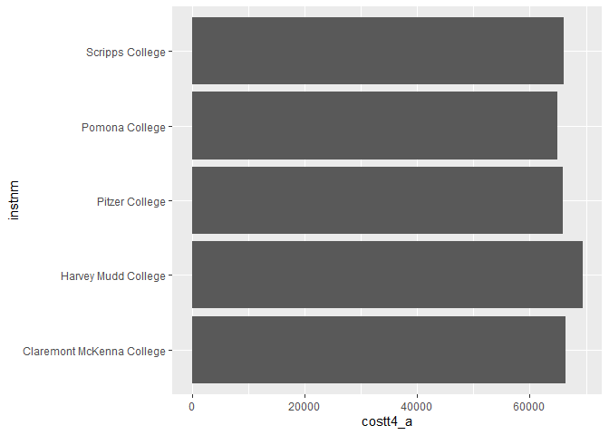

```r
colleges %>%
  filter(city == 'Claremont') %>%
  filter(costt4_a != 'NA') %>%
  ggplot(aes(x = instnm, y = costt4_a)) + geom_col()+ coord_flip()
```

6. The column `ADM_RATE` is the admissions rate by college and `C150_4_POOLED` is the four-year completion rate. Use a scatterplot to show the relationship between these two variables. What do you think this means?

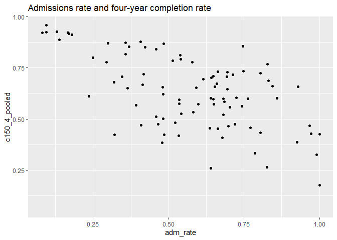

```r
colleges %>%
  select(adm_rate, c150_4_pooled) %>%
  ggplot(aes(x = adm_rate, y = c150_4_pooled)) + geom_point(na.rm = T) + labs(title = 'Admissions rate and four-year completion rate')
```

```r
# There is a weak negative correlation between admission rate and four-year completion rate
```

7. Is there a relationship between cost and four-year completion rate? (You don’t need to do the stats, just produce a plot). What do you think this means?

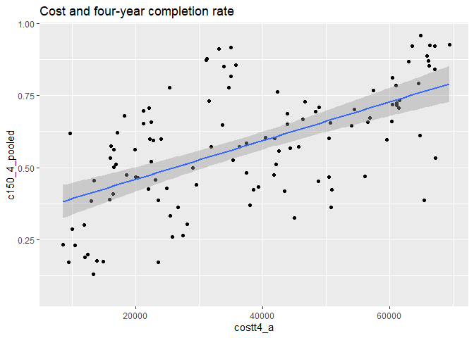

```r
colleges %>%
  select(costt4_a, c150_4_pooled) %>%
  ggplot(aes(x = costt4_a, y = c150_4_pooled)) + geom_point(na.rm = T) + labs(title = 'Cost and four-year completion rate') + geom_smooth(method = lm, se=T, na.rm = T)
```

```r
test <- chisq.test(table(colleges$costt4_a, colleges$c150_4_pooled))
test
```

```
##
##  Pearson's Chi-squared test
##
## data:  table(colleges$costt4_a, colleges$c150_4_pooled)
## X-squared = NaN, df = 24840, p-value = NA
```

```r
#There is a weak positive correlation between cost and four-year completion rate
```

8. The column titled `INSTNM` is the institution name. We are only interested in the University of California colleges. Make a new data frame that is restricted to UC institutions. You can remove `Hastings College of Law` and `UC San Francisco` as we are only interested in undergraduate institutions.

```r
UCcolleges <- data.frame(colleges)
UCcolleges
```

[output not shown]

[output cut: 1011 more lines]

Remove `Hastings College of Law` and `UC San Francisco` and store the final data frame as a new object `univ_calif_final`.

```r
univ_calif_final <- UCcolleges %>%
filter(str_detect(instnm, 'University of California')) %>%
         filter(instnm != 'University of California-Hastings College of Law') %>%
  filter(instnm != 'University of California-San Francisco')
univ_calif_final
```

```
##                                   instnm          city stabbr        zip
## 1     University of California-San Diego      La Jolla     CA      92093
## 2        University of California-Irvine        Irvine     CA      92697
## 3     University of California-Riverside     Riverside     CA      92521
## 4   University of California-Los Angeles   Los Angeles     CA 90095-1405
## 5         University of California-Davis         Davis     CA 95616-8678
## 6    University of California-Santa Cruz    Santa Cruz     CA 95064-1011
## 7      University of California-Berkeley      Berkeley     CA      94720
## 8 University of California-Santa Barbara Santa Barbara     CA      93106
##   adm_rate sat_avg pcip26 costt4_a c150_4_pooled pftftug1_ef
## 1   0.3566    1324 0.2165    31043        0.8724      0.6622
## 2   0.4065    1206 0.1073    31198        0.8764      0.7254
## 3   0.6634    1078 0.1491    31494        0.7300      0.8111
## 4   0.1799    1334 0.1548    33078        0.9112      0.6607
## 5   0.4228    1218 0.1975    33904        0.8502      0.6049
## 6   0.5785    1201 0.1927    34608        0.7764      0.7856
## 7   0.1693    1422 0.1053    34924        0.9165      0.7087
## 8   0.3577    1281 0.1075    34998        0.8157      0.7077
```

Use `separate()` to separate institution name into two new columns “UNIV” and “CAMPUS”.

```r
separate(univ_calif_final, instnm, into = c('UNIV', 'CAMPUS'), sep = '-')
```

```
##                       UNIV        CAMPUS          city stabbr        zip
## 1 University of California     San Diego      La Jolla     CA      92093
## 2 University of California        Irvine        Irvine     CA      92697
## 3 University of California     Riverside     Riverside     CA      92521
## 4 University of California   Los Angeles   Los Angeles     CA 90095-1405
## 5 University of California         Davis         Davis     CA 95616-8678
## 6 University of California    Santa Cruz    Santa Cruz     CA 95064-1011
## 7 University of California      Berkeley      Berkeley     CA      94720
## 8 University of California Santa Barbara Santa Barbara     CA      93106
##   adm_rate sat_avg pcip26 costt4_a c150_4_pooled pftftug1_ef
## 1   0.3566    1324 0.2165    31043        0.8724      0.6622
## 2   0.4065    1206 0.1073    31198        0.8764      0.7254
## 3   0.6634    1078 0.1491    31494        0.7300      0.8111
## 4   0.1799    1334 0.1548    33078        0.9112      0.6607
## 5   0.4228    1218 0.1975    33904        0.8502      0.6049
## 6   0.5785    1201 0.1927    34608        0.7764      0.7856
## 7   0.1693    1422 0.1053    34924        0.9165      0.7087
## 8   0.3577    1281 0.1075    34998        0.8157      0.7077
```

9. The column `ADM_RATE` is the admissions rate by campus. Which UC has the lowest and highest admissions rates? Produce a numerical summary and an appropriate plot.

```r
univ_calif_final %>%
  select(instnm, adm_rate) %>%
  arrange(desc(adm_rate))
```

```
##                                   instnm adm_rate
## 1     University of California-Riverside   0.6634
## 2    University of California-Santa Cruz   0.5785
## 3         University of California-Davis   0.4228
## 4        University of California-Irvine   0.4065
## 5 University of California-Santa Barbara   0.3577
## 6     University of California-San Diego   0.3566
## 7   University of California-Los Angeles   0.1799
## 8      University of California-Berkeley   0.1693
```

[figure not shown]

```r
univ_calif_final %>%
  ggplot(aes(x = instnm, y = adm_rate)) + geom_col()
```

10. If you wanted to get a degree in biological or biomedical sciences, which campus confers the majority of these degrees? Produce a numerical summary and an appropriate plot.

```r
univ_calif_final %>%
  select(instnm, pcip26) %>%
  arrange(desc(pcip26))
```

```
##                                   instnm pcip26
## 1     University of California-San Diego 0.2165
## 2         University of California-Davis 0.1975
## 3    University of California-Santa Cruz 0.1927
## 4   University of California-Los Angeles 0.1548
## 5     University of California-Riverside 0.1491
## 6 University of California-Santa Barbara 0.1075
## 7        University of California-Irvine 0.1073
## 8      University of California-Berkeley 0.1053
```

[figure not shown]

```r
univ_calif_final %>%
  ggplot(aes(x = instnm, y = pcip26)) + geom_col()
```

## Knit Your Output and Post to [GitHub](https://github.com/FRS417-DataScienceBiologists)